# Milestone Report

Florian Dollak

17 Mai 2018

## Management Summary

This report gives a quick status overview over the creation of a prediction model for phrases and sentences. For this purpose an app will be created to demonstrate the model and how the next word is predicted based on previous user input.

The main goal of this app is to implement the model and predict the next word in common web-based contexts. To achieve this, a prediction model for the english language is constructed based on various text sources on the net. This report features the exploratory analysis of the provided text data and offers insight into the thought process behind the initial model creation.

## Basic Data Summary

First, an overview about basic properties of the data used. The initial datasets consist of english news-articles, blog-posts and twitter messages. After loading the data, samples are created for the first model to keep the processing effort low.

### Text Example

```
## [1] "There are far less draconian changes that could be made to narrow the long-term funding gap, such as raising the cap on wages subject to payroll taxes. But these measures become less sufficient each year Congress waits to put them into effect. At the very least, lawmakers will have to addres…
```

### Word Counts, Line Counts and other info

| Filename | Filesize [MB] | Linecount | Wordcount |
| --- | --- | --- | --- |
| Blogs | 200.42 | 899288 | 37599515 |
| News | 159.36 | 2360148 | 30093410 |
| Twitter | 196.28 | 77259 | 2674536 |
| OANC | 92.26 | 1463146 | 14728941 |

### Exploratory Graphs

Here an overview over the most common words in the text sample:

#### Word Cloud

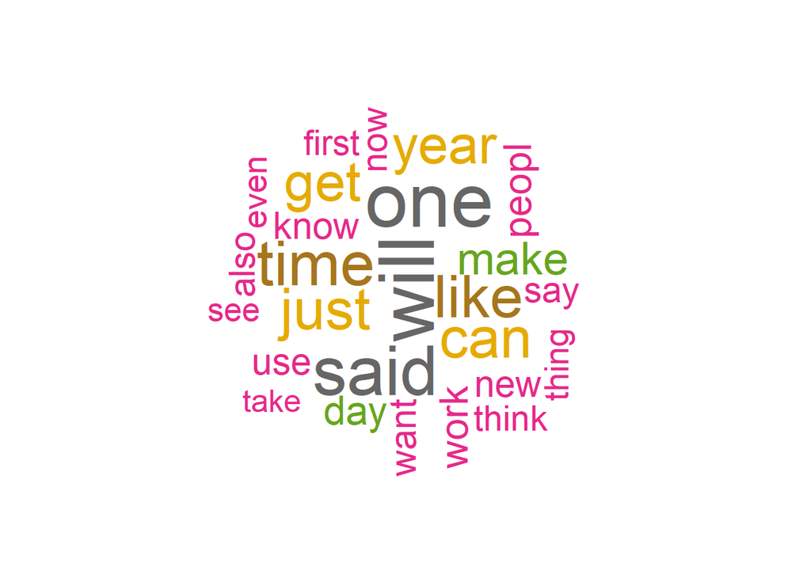

#### Histogram

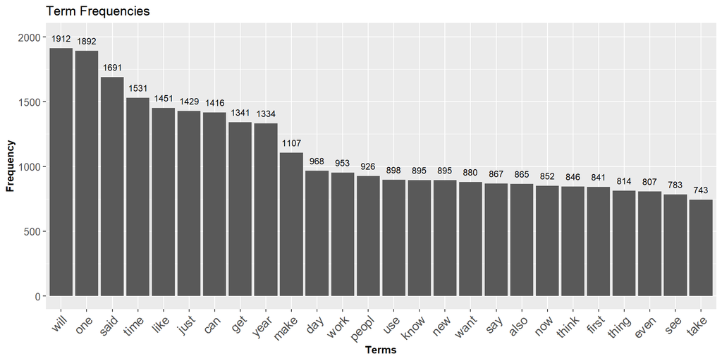

#### Radar Plot

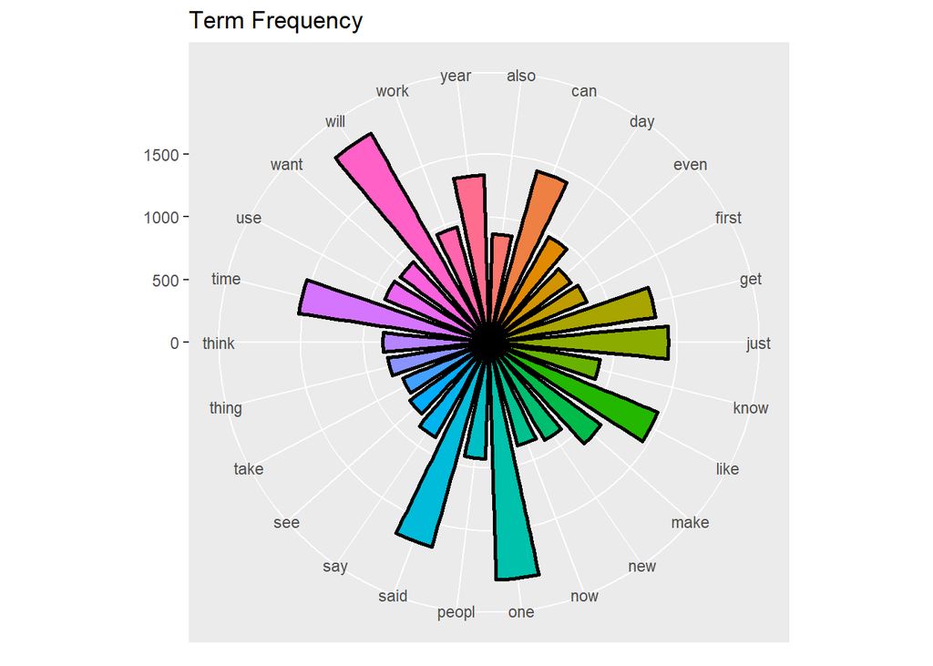

### Most common 2- and 3-word phrases

And here also an overview about common phrases in the text sample. Some of the phrases are commonalities in the english language e.g. feel like, make sure. In the three word phrases there are also many names like “new york time”, “presid barack obama” et cetera.

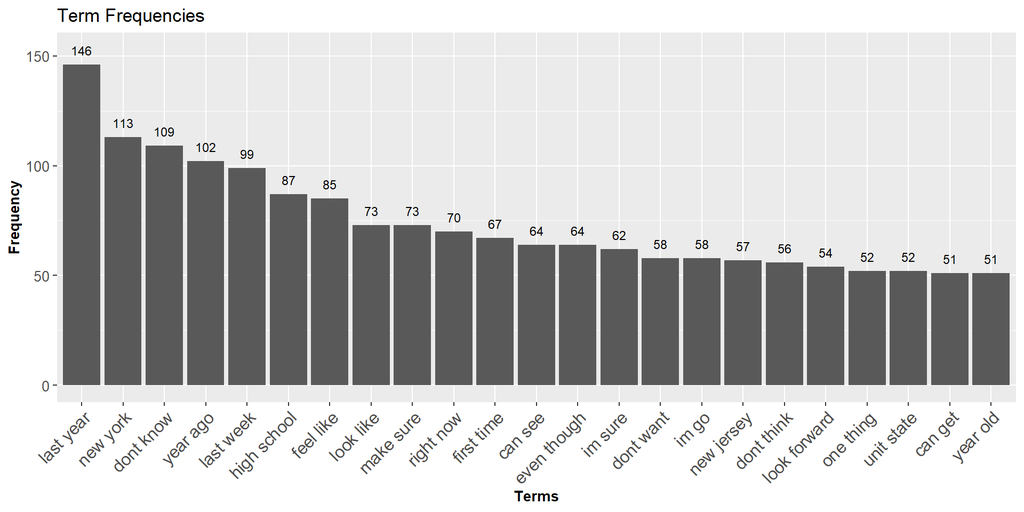

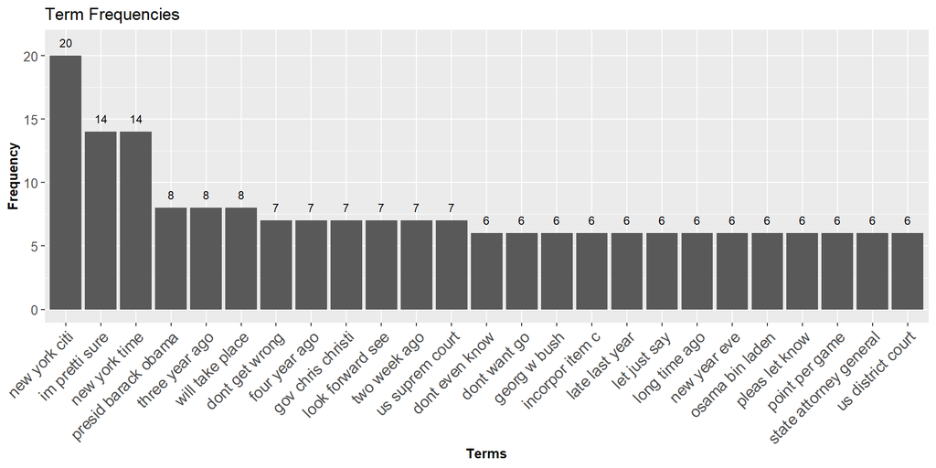

## Outline

The goal for the initial prediciton model is to expand the prediction to multiple-word phrases/sentences and generalize this concept for unseen words that do not appear in the training data. In order to maximize the accuracy of the model the plan is to use an extended training set to maximize model fit and subsequently finetune the model for performance to find the sweet spot between performance and accuracy.